# Fourier Analysis (Introduction)

### How come we can shift the frequencies?

When we were talking about the horizontal axis' meaning and how to obtain the correct window with respect to the sampling rate, we easily shifted the frequencies on the right side to the negative region.

We've already saw that, when the signal is real, half of the frequencies' coefficients will be equal to the other half's coefficients' complex conjugate values. Furthermore, these corresponding pairs' ($k, N-k$) frequencies will be "inverse" to each other. (What does a 'negative frequency' mean by the way?! 8)

For the moment, let's show that waves with frequencies $\left(\frac{k}{N}\right)$ and $\left(\frac{k}{N} + mN\right)$ are equal to each other (with $\{k,N,m,n\}\in\mathbb{Z}$, $m$ arbitrary, $\{k,n\}=0\dots N-1$), so here we go:

$$\begin{align*}\cos\left[2\pi\left(\frac{k}{N} + mN\right) n\right] &= \cos\left(\frac{2\pi kn}{N} + 2\pi mNn\right)\\ &=\cos\left(\frac{2\pi kn}{N}\right)\cos\left(2\pi mNn\right)-\sin\left(\frac{2\pi kn}{N}\right)\sin\left(2\pi mNn\right) \end{align*} $$

where we have used the trigonometric identity: $\cos(\alpha+\beta) \equiv \cos\alpha \cos\beta - \sin\alpha \sin\beta$. Out critical term is the $\left(2\pi mNn\right)$ and more specifically $mNn$ in there. As all $m,N,n$ are integers, that parantheses is nothing but $2\pi$ multiplied by an integer, say $a$, and we all know how that goes for cosine and sine (given $a\in\mathbb{Z}$):

$$\cos(2\pi a) = 1,\quad \sin(2\pi a) = 0\quad\quad\left(a\in\mathbb{Z}\right)$$

Placing this equivalency in the above equation, we get: $$\begin{align*}\cos\left[2\pi\left(\frac{k}{N} + mN\right) n\right] &=\cos\left(\frac{2\pi kn}{N}\right)\underbrace{\cos\left(2\pi\overbrace{ mNn}^{\in\mathbb{Z}}\right)}_{1}-\sin\left(\frac{2\pi kn}{N}\right)\underbrace{\sin\left(2\pi \overbrace{ mNn}^{\in\mathbb{Z}}\right)}_{0}\\ &=\cos\left(\frac{2\pi kn}{N}\right)=\cos\left[2\pi\left(\frac{k}{N}\right)n\right] \end{align*}$$

Hence, we can add/subtract as many $N$ as we want to/from the frequency (thus *shifting* it) as long as we do it in integer multiplers of $N$.

When we look at it this way, maybe it isn't that impressive, however, from applicational point of view, we are boldly stating that even if the frequency is changed by a significant amount, no additional information will be gained regarding the data.

To see how this works, we will consider a very small system with $N = 5$ and $k=3$. The corresponding frequency will be: $\frac{k}{N}=\frac{3}{5}$, so let's plot it:

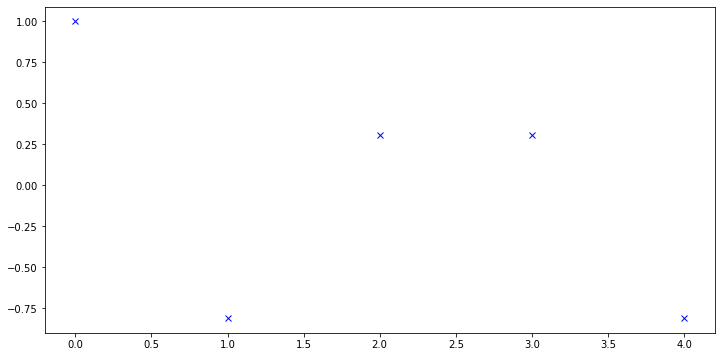

```python
N = 5
k = 3
f = k/N

n = np.arange(N)
y = np.cos(2*np.pi*f*n) # These are our data
plt.plot(n,y,"bx")
plt.show()
```

As we know the underlying frequency, let's also put it in:

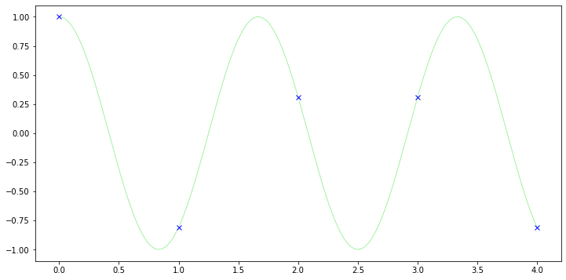

```python
x = np.linspace(0,N-1,1000)
c = np.cos(2*np.pi*f*x)
plt.plot(x,c,"-",color="lightgreen",lw=0.8)
plt.plot(n,y,"bx")
plt.show()
```

Keep in mind that, we are making our calculations exactly at the integer values ($n=0,\dots,N-1$). The pale continous line (whose frequency is equal to $\tfrac{k}{N}$) is something we are not interested except at the integer parameter values.

Obviously, two waves with different frequencies will have very distinct graphs (duh!). As the frequency increases, the number of oscillations per unit length/time will also increase. So, let's plot the above wave of frequency $\tfrac{k}{N} = \tfrac{3}{5}$ along with another wave of frequency $\tfrac{k}{N}+mN = \tfrac{3}{5}+(2\times 5) = \tfrac{53}{5}$:

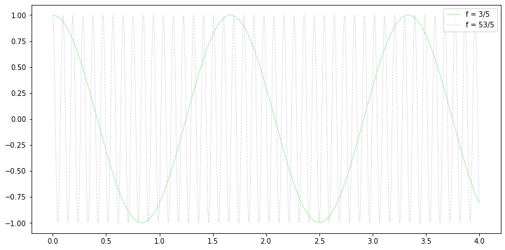

```python
N = 5
k = 3
m = 2

x = np.linspace(0,N-1,1000)
f1 = k/N
f2 = k/N + m*N
c1 = np.cos(2*np.pi*f1*x)
c2 = np.cos(2*np.pi*f2*x)

plt.plot(x,c1,"-",color="lightgreen",lw=0.8)
plt.plot(x,c2,"--",color="lightgray",lw=0.8)
plt.legend(["f = 3/5","f = 53/5"],loc="upper right")
plt.show()
```

Nothing surprising here, as they are two waves as different as two waves with different frequencies can be! So how in the first place we could believe that there is no difference and we can take these as equivalent?!!!

The answer lies in the fact that we are only taking the integer parameters into account. Check the above graph with the points placed:

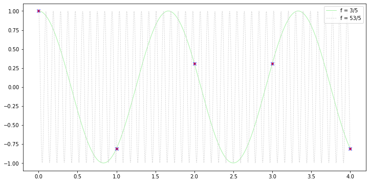

```python
N = 5
k = 3
m = 2

x = np.linspace(0,N-1,1000)
f1 = k/N
f2 = k/N + m*N
c1 = np.cos(2*np.pi*f1*x)
c2 = np.cos(2*np.pi*f2*x)

points1 = np.cos(2*np.pi*f1*n)
points2 = np.cos(2*np.pi*f2*n)

plt.plot(x,c1,"-",color="lightgreen",lw=0.8)
plt.plot(x,c2,"--",color="lightgray",lw=0.8)
plt.plot(n,points1,"xb")
plt.plot(n,points1,"+r")
plt.legend(["f = 3/5","f = 53/5"],loc="upper right")
plt.show()
```

Zooming in:

[figure not shown]

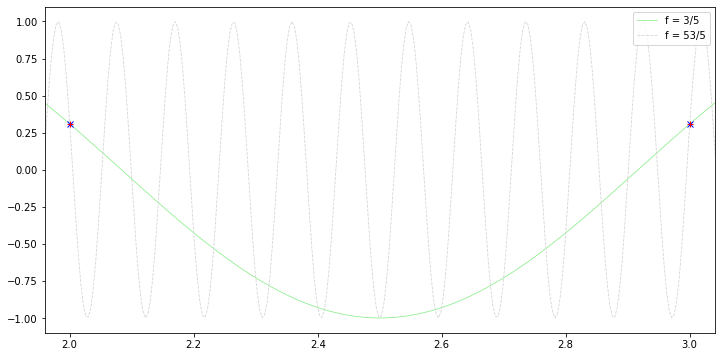

```python
plt.plot(x,c1,"-",color="lightgreen",lw=0.8)
plt.plot(x,c2,"--",color="lightgray",lw=0.8)
plt.plot(n,points1,"xb")
plt.plot(n,points1,"+r")
plt.legend(["f = 3/5","f = 13/5"],loc="upper right")
plt.xlim([0.96,3.04])
plt.show()

plt.plot(x,c1,"-",color="lightgreen",lw=0.8)
plt.plot(x,c2,"--",color="lightgray",lw=0.8)
plt.plot(n,points1,"xb")
plt.plot(n,points1,"+r")
plt.legend(["f = 3/5","f = 53/5"],loc="upper right")
plt.xlim([1.96,3.04])
plt.show()
```

meaning, as long as we are only interested in the integer parameters, all the $f = \tfrac{k}{N} + mN$ frequencies point to the same data, same information! (This fact is utilized beautifully in solid state physics, when we are dealing with phonons.)

### One last remark..

To see the positive and "negative" frequencies in action, Let's start from the beginning. Let's take our sample case once again:

$$x(t) = 3.2 \cos(2\pi (3) t)$$

from which we see that: Amplitude (A): 3.2 Frequency (f): 3

Now, let's try to write it as an addition of two complex waves with their amplitudes being complex conjugates of each other and also their frequencies being negative of each other:

$$\begin{align*}y_1 &= \left(a+ib\right)\left[\cos\left(2\pi (f) t\right) + i \sin\left(2\pi (f) t\right)\right]\\ y_2 &= \left(a-ib\right)\left[\cos\left(2\pi(-f) t\right) + i \sin\left(2\pi (-f) t\right)\right] \end{align*}$$

Before we proceed further, please check for yourself to see that the amplitudes of the two complex waves are indeed complex conjugates of each other and also the frequencies are negative of each other as well.

Let's add these two waves. Expanding the parantheses:

$$\begin{gather*}y_1 + y_2 = \left(a+ib\right)\left[\cos\left(2\pi (f) t\right) + i \sin\left(2\pi (f) t\right)\right] + \left(a-ib\right)[\underbrace{\cos\left(2\pi(-f) t\right)}_{\cos\left(2\pi(f) t\right)} + i \,\underbrace{\sin\left(2\pi (-f) t\right)}_{-\sin\left(2\pi (f) t\right)}]\\ =\left[a\cos\left(2\pi f t\right)+ia\sin\left(2\pi f t\right)+ib\cos\left(2\pi f t\right)-b\sin\left(2\pi f t\right)\right] + \left[a\cos\left(2\pi f t\right)-ia\sin\left(2\pi f t\right)-ib\cos\left(2\pi f t\right)-b\sin\left(2\pi f t\right)\right]\\ =\boxed{2a\cos\left(2\pi f t\right) - 2b\sin\left(2\pi f t\right)} \end{gather*}$$

Comparing this with the above $x(t) = 3.2 \cos(2\pi (3) t)$, it is obvious that:

- a = 1.6
- b = 0
- f = 3 such that: $$\begin{align*}y_1 &= 1.6\left[\cos(2\pi(3)t) + i\sin(2\pi(3)t)\right]\\ y_2 &= 1.6\left[\cos(2\pi(-3)t) + i\sin(2\pi(-3)t)\right]\\&= 1.6\left[\cos(2\pi(3)t) - i\sin(2\pi(3)t)\right]\end{align*}$$

If our initial pure signal was that of a sine wave, say:

$$x(t) = 3.2 \sin(2\pi (3) t)$$

then, to comply, our positive and negative frequency pair would obviously be:

$$\begin{align*}y_1 &= (-1.6i)\left[\cos(2\pi(3)t) + i\sin(2\pi(3)t)\right]\\ y_2 &= (1.6i)\left[\cos(2\pi(-3)t) + i\sin(2\pi(-3)t)\right]\\&= (1.6i)\left[\cos(2\pi(3)t) - i\sin(2\pi(3)t)\right]\end{align*}$$

```python
A = 3.2
f = 3.
N = 50000
tt = np.linspace(0,4,N)

x_cos = A*np.cos(2*np.pi*f*tt)
X_cos = np.fft.fft(x_cos)/N
X_cos_a = np.abs(X_cos)
X_cos_a_normalized = X_cos_a / np.max(X_cos_a)
X_filter = X_cos_a_normalized>1E-1
fft_freq = np.fft.fftfreq(N,4/N)
print("## Cosine Wave ##")
print("Picked Frequencies: {:.3f}, {:.3f}".format(*fft_freq[X_filter]))
print("Corresponding Amplitudes: {:.3f}, {:.3f}".format(*X_cos[X_filter]))

print("-"*45)

x_sin = A*np.sin(2*np.pi*f*tt)
X_sin = np.fft.fft(x_sin)/N
X_sin_a = np.abs(X_sin)
X_sin_a_normalized = X_sin_a / np.max(X_sin_a)
X_filter = X_sin_a_normalized>1E-1
fft_freq = np.fft.fftfreq(N,4/N)
print("## Sine Wave ##")
print("Picked Frequencies: {:.3f}, {:.3f}".format(*fft_freq[X_filter]))
print("Corresponding Amplitudes: {:.3f}, {:.3f}".format(*X_sin[X_filter]))
```

```
## Cosine Wave ##
Picked Frequencies: 3.000, -3.000
Corresponding Amplitudes: 1.600+0.001j, 1.600-0.001j
---------------------------------------------
## Sine Wave ##
Picked Frequencies: 3.000, -3.000
Corresponding Amplitudes: 0.001-1.600j, 0.001+1.600j
```

## Fast Fourier Transform (FFT)

In the above "Manual Transform" section, we have computed the Fourier transform using the classic formulation. However, with the advance of computing power and development of sparse matrix toolkits, a faster way $\left(O\left(N^2\right)\Rightarrow O(N \log N)\right)$) for Fourier transform has been devised in the 1960s by James Cooley and John Tukey.

We won't be dealing with how the method works but will directly benefit from it. Using it is as simple as typing [`fft`](https://numpy.org/doc/stable/reference/generated/numpy.fft.fft.html):

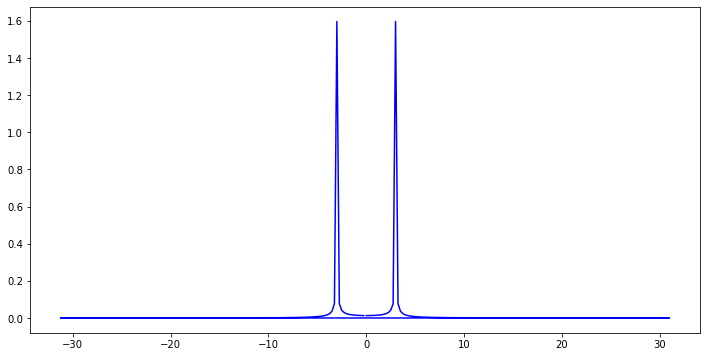

```python
# Define our signal
N = 250 # Number of samples
t = np.linspace(0,4,N)
T = 1/3 # Period
A = 3.2 # Amplitude

i2pi_N = 2j*np.pi/N

x = A * np.cos(2 * np.pi / T * t)

# Transform it via FFT
X_FFT = np.fft.fft(x)
X_FFT /= N
# Calculate the corresponding frequencies via fftfreq
ff = np.fft.fftfreq(N,4/N)

# Plot it
plt.plot(ff, np.abs(X_FFT), "b-")
plt.show()
```

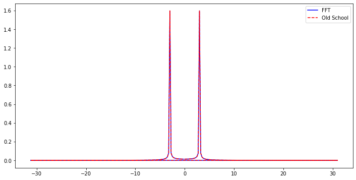

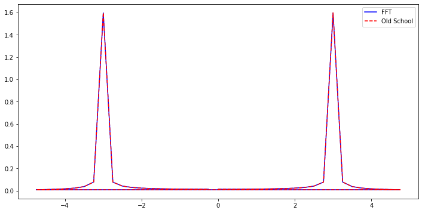

```python
# Compare it with the "manual" section's result
plt.plot(ff, np.abs(X_FFT), "b-")
plt.plot(ff, np.abs(X), "r--")
plt.legend(["FFT","Old School"])
plt.show()

window_filter = np.abs(ff) < 5
plt.plot(ff[window_filter], np.abs(X_FFT[window_filter]), "b-")
plt.plot(ff[window_filter], np.abs(X[window_filter]), "r--")
plt.legend(["FFT","Old School"])
plt.show()
```

# Case Studies

## 1. The brotherhood of cosines

Up until now, we had a pure sinusoidal (cosine) signal, let's pepper up the signal by combining 3 waves:

```python
# Generate the ideal signal
N = 48000 # Number of high res "sample"
t = np.linspace(0,1,N)

freqs = [95,300,677] # Hz
amps  = [0.97,3.23,2.617]
num_freqs = len(freqs)

two_pi_t = 2 * np.pi * t

x = np.zeros(N)
for i in range(num_freqs):
    x += amps[i]*np.cos(two_pi_t*freqs[i])
```

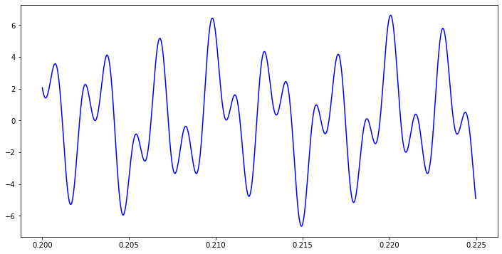

```python
# Plot
time_interval_window = [0.2,0.225]
n1 = np.arange(N)[t>=time_interval_window[0]][0]
n2 = np.arange(N)[t>=time_interval_window[1]][0]

plt.plot(t[n1:n2],x[n1:n2],"b-")
plt.show()
```

```python
# FFT decomposition
xt = np.fft.fft(x)
xt = xt[:int(N/2)] # remove the symmetrical frequencies
xt_abs = np.abs(xt)

# Fix the amplitudes
xt_abs = xt_abs/xt.size

# Filter the weak components
xt_norm = xt_abs / np.max(xt_abs)
freqs_recon = []
for i in np.arange(int(N/2))[xt_norm>0.25]:
    print("{:3d} : {:.3f}".format(i,xt_abs[i]))
    freqs_recon.append(i)
```

```
 95 : 0.970
300 : 3.230
677 : 2.616
```

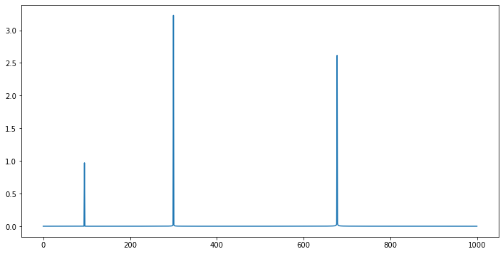

```python
freq_upto = 1000
plt.plot(range(freq_upto),xt_abs[:freq_upto])
plt.show()
```

So, there we have it, exactly as given. However, we did it with a high number of samples ($N=48000$). Which brings us to the next lesson (again)...

### The importance of the number of samples (in regard to frequency splittings)

The amplitudes are accurate when the number of samples are high. Let's quickly re-do the above processes this time with a lower *N*:

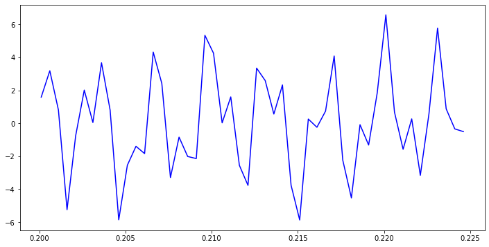

```
 95 : 0.973
300 : 3.116
677 : 2.145
678 : 1.098
```

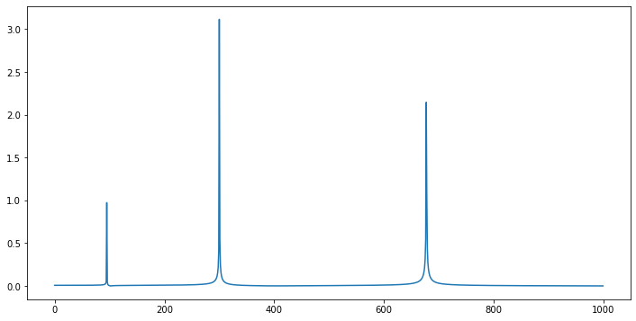

```python
# Generate the ideal signal
n_low = 2000 # Number of low res "sample"
t_low = np.linspace(0,1,n_low)

freqs = [95,300,677] # Hz
amps  = [0.97,3.23,2.61]
num_freqs = len(freqs)

two_pi_t_low = 2 * np.pi * t_low

x_low = np.zeros(n_low)
for i in range(num_freqs):
    x_low += amps[i]*np.cos(two_pi_t_low*freqs[i])

# Plot
time_interval_window = [0.2,0.225]
n1 = np.arange(n_low)[t_low>=time_interval_window[0]][0]
n2 = np.arange(n_low)[t_low>=time_interval_window[1]][0]

plt.plot(t_low[n1:n2],x_low[n1:n2],"b-")
plt.show()

# FFT decomposition
xt_low = np.fft.fft(x_low)
xt_low = xt_low[:int(n_low/2)] # remove the symmetrical frequencies
xt_abs_low = np.abs(xt_low)

# Fix the amplitudes
xt_abs_low = xt_abs_low/xt_low.size

# Filter the weak components
xt_norm_low = xt_abs_low / np.max(xt_abs_low)
freqs_recon_low = []
for i in np.arange(int(n_low/2))[xt_norm_low>0.25]:
    print("{:3d} : {:.3f}".format(i,xt_abs_low[i]))
    freqs_recon_low.append(i)

freq_upto_low = 1000
plt.plot(range(freq_upto_low),xt_abs_low[:freq_upto_low])
plt.show()
```

as can be seen there is a splitting of the high frequency. (677, but also *678*)

**Finding the amplitudes (only cosines case)**

Now that we have the frequencies pinned down, it is more or less straightforward to fine tune the amplitudes via least squares fitting method (or any other optimization algorithm). We have 3 unknown amplitudes $\vec{A} = \{A^{(0)}, A^{(1)}, A^{(2)}\}$ for the three frequencies $\{f^{(0)}, f^{(1)}, f^{(2)}\}$ and $n$ equations such that:

$$\begin{align*}A^{(0)}\cos(2\pi f^{(0)}t_0) + A^{(1)}\cos(2\pi f^{(1)}t_0) + A^{(2)}\cos(2\pi f^{(2)}t_0) &= x_0\\ \vdots \\ A^{(0)}\cos(2\pi f^{(0)}t_i) + A^{(1)}\cos(2\pi f^{(1)}t_i) + A^{(2)}\cos(2\pi f^{(2)}t_i) &= x_i\\ \vdots \\ A^{(0)}\cos(2\pi f^{(0)}t_{n-1}) + A^{(1)}\cos(2\pi f^{(1)}t_{n-1}) + A^{(2)}\cos(2\pi f^{(2)}t_{n-1}) &= x_{n-1} \end{align*}$$

which can be written as a matrix multiplication:

$$\underbrace{\begin{pmatrix}\cos(2\pi f^{(0)}t_0) && \cos(2\pi f^{(1)}t_0) && \cos(2\pi f^{(2)}t_0)\\ \vdots&&\vdots&&\vdots\\ \cos(2\pi f^{(0)}t_{n-1}) && \cos(2\pi f^{(1)}t_{n-1}) && \cos(2\pi f^{(2)}t_{n-1})\end{pmatrix}_{(n\times3)}}_{\mathbb{C}} \underbrace{\begin{pmatrix}A^{(0)}\\A^{(1)}\\A^{(2)}\end{pmatrix}_{(3\times1)}}_{\vec{A}} = \underbrace{\begin{pmatrix}x_0\\\vdots \\x_i\\\vdots \\x_{n-1}\end{pmatrix}_{(n\times1)}}_{\vec{x}} $$$${\mathbb{C}}\cdot\vec{A}=\vec{x}$$

This is an overdetermined set of linear equations (3 unknowns and n>3 equations), so least squares fitting is a suitable choice of attack:

```python
C=np.empty((0,t.size))
for f in freqs_recon:
    C = np.vstack([C,np.cos(two_pi_t*f)])
C = C.T
print(C)
```

```
[[1.         1.         1.        ]
 [0.99992268 0.999229   0.99607573]
 [0.99969072 0.99691721 0.98433374]
 ...
 [0.99969072 0.99691721 0.98433374]
 [0.99992268 0.999229   0.99607573]
 [1.         1.         1.        ]]
```

```python
amps_recon =  np.linalg.lstsq(C,x,rcond=None)[0]
print(("{:.3f} | "*amps_recon.size).format(*amps_recon))
```

```
0.970 | 3.230 | 2.617 |
```

Mind though, this working out the amplitudes straightforward is not a general approach, it worked here because there were only cosines involved. But no worries, before the lecture ends, we'll have a general approach (involving least squares fitting) in our hands.

**Moral of the story:** Always eyeball the calculations, make your estimations before you see the results and don't leave it all to computer, because the computer always returns a result.

**Secondary -scientific- moral of the story:** The frequencies are the essential targets - once you find them, correct amplitudes can be derived easily, so, focus on the frequencies, and the rest will follow.

## 2. Noisy signal

When we filtered out the "weak" frequencies in the spectrum above (the `xt_norm_low>0.25` line), we started something new: we based our reasoning that the signal was composed of a couple of "strong" signals and the rest was "noise". So, let's add some actual random noise to our signal:

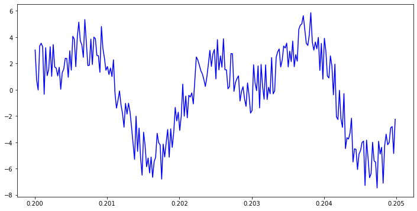

```python
# Noise
nz = 2*(np.random.rand(N)*2-1)
x_nz = x + nz

# Plot
time_interval_window = [0.2,0.205]
n1 = np.arange(N)[t>=time_interval_window[0]][0]
n2 = np.arange(N)[t>=time_interval_window[1]][0]

plt.plot(t[n1:n2],x_nz[n1:n2],"b-")
plt.show()
```

Fourier transform reveals the active frequencies:

```
 95 : 0.962
300 : 3.230
677 : 2.640
```

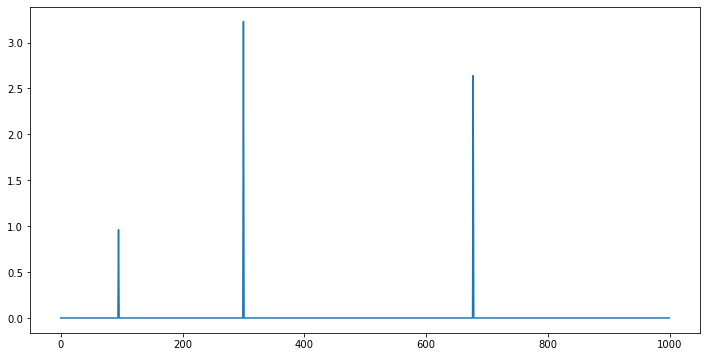

```python
# FFT decomposition
xt_nz = np.fft.fft(x_nz)
xt_nz = xt_nz[:int(N/2)] # remove the symmetrical frequencies
xt_abs_nz = np.abs(xt_nz)

# Fix the amplitudes
xt_abs_nz = xt_abs_nz/xt_nz.size

# Filter the weak components
xt_norm_nz = xt_abs_nz / np.max(xt_abs_nz)
freqs_recon_nz = []
for i in np.arange(int(N/2))[xt_norm_nz>0.25]:
    print("{:3d} : {:.3f}".format(i,xt_abs_nz[i]))
    freqs_recon_nz.append(i)

# Remove the noise frequencies
xt_abs_nz[xt_norm_nz<0.25] = 0.

freq_upto = 1000
plt.plot(range(freq_upto),xt_abs_nz[:freq_upto])
plt.show()
```

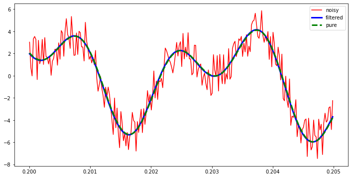

```python
# Recover the pure signal by constructing from the filtered frequencies
xt_nz_filtered = np.fft.fft(x_nz)
xt_nz_filtered_abs = np.abs(xt_nz_filtered)
xt_nz_filtered[xt_nz_filtered_abs/np.max(xt_nz_filtered_abs)<0.25] = 0.
x_recon = np.real(np.fft.ifft(xt_nz_filtered))

# Plot
time_interval_window = [0.2,0.205]
n1 = np.arange(N)[t>=time_interval_window[0]][0]
n2 = np.arange(N)[t>=time_interval_window[1]][0]

plt.plot(t[n1:n2],x_nz[n1:n2],"r-")
plt.plot(t[n1:n2],x_recon[n1:n2],"b-",linewidth=3)
plt.plot(t[n1:n2],x[n1:n2],"g--",linewidth=3)
plt.legend(["noisy","filtered","pure"])
plt.show()
```

Job done!

## 3. A slightly more complex case (with sine added)

```python
N = 4000
freqs = [200, 343, 576, 900]
amps  = [1.2, 0.97, 1.13, 1.17]
funcs = [np.cos, np.cos, np.sin, np.cos]

t = np.linspace(0,2,N)

two_pi_t = 2*np.pi*t

signal = np.zeros(N,float)
for i in range(len(freqs)):
    signal += amps[i] * funcs[i](two_pi_t*freqs[i])
```

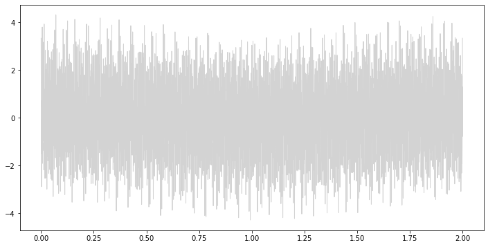

```python
plt.plot(t,signal,color="lightgray",linewidth=1)
plt.show()
```

So, this is our signal, in all its glory. Our "recording" duration is 2 seconds, with 4000 samples *(we have forgotten its constituents: as of now we don't know the involved functions, their frequencies, their amplitudes, not even how many there are)*.

Zooming in, it looks like this:

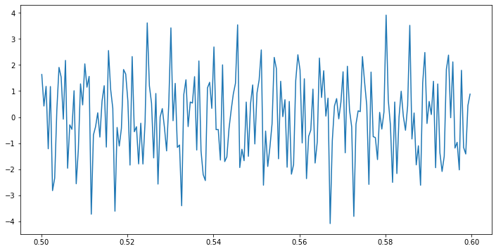

```python
time_window = [0.50,0.60]
t_filter = (t>=time_window[0]) & (t<=time_window[1])

plt.plot(t[t_filter], signal[t_filter])
plt.show()
```

So, let's apply FFT to the signal:

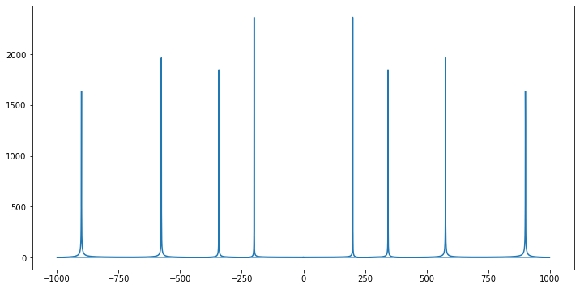

```python
signal_fft = np.fft.fft(signal)
ff = np.fft.fftfreq(N,2/N)

plt.plot(ff, np.abs(signal_fft))
plt.show()
```

Pick the peaks from the positive range:

```python
peak_indices_filter = np.abs(signal_fft)>1000
freqs_recon_all = ff[peak_indices_filter]
freqs_recon_positive = freqs_recon_all[freqs_recon_all>0]
print(freqs_recon_positive)

indices_picked = []
for i in np.arange(N)[peak_indices_filter]:
    if(ff[i]>0):
        indices_picked.append(i)
        print("[#{:4d}] {:6.2f} : {:7.3f}".format(i,ff[i],
                                2*np.abs(signal_fft)[i]/N))
indices_picked
```

```
[200.  343.  576.  900.  900.5]
[# 400] 200.00 :   1.182
[# 686] 343.00 :   0.924
[#1152] 576.00 :   0.982
[#1800] 900.00 :   0.818
[#1801] 900.50 :   0.668
```

```
[400, 686, 1152, 1800, 1801]
```

Instead of problem-specific filtering with amplitudes greater than 1000, a general solution of filtering above 50% of the normalized amplitudes can be used as well. In order to do so, we normalize the amplitudes and take the ones that are greater than 0.5 (i.e., > 50%) (We have already did it like this in the above cases, and this is the reason why we did it in that way: to generalize the code)

```python
signal_fft_abs = np.abs(signal_fft)
signal_fft_abs_normalized = signal_fft_abs / np.max(signal_fft_abs)
f_norm_filter = signal_fft_abs_normalized>0.5
ffreq = np.fft.fftfreq(N,2/N)
ffreq_pos_filter = ffreq > 0
f_filter = (f_norm_filter) & (ffreq_pos_filter)
indices_picked = np.arange(N)[f_filter]
print(indices_picked)
```

```
[ 400  686 1152 1800 1801]
```

The frequencies are caught very well except for the smearing of the highest frequency. This kind of "splittings" may occur near the high frequency range with a low number of samples (as we've seen and investigated in the "The importance of the number of samples (in regard to frequency splittings)" section above).

We have the frequencies, have the amplitudes and also can reconstruct the signal using the inverse fourier transform (mind how we multiply the coefficients by 2 to also count for the negative frequency contributions)

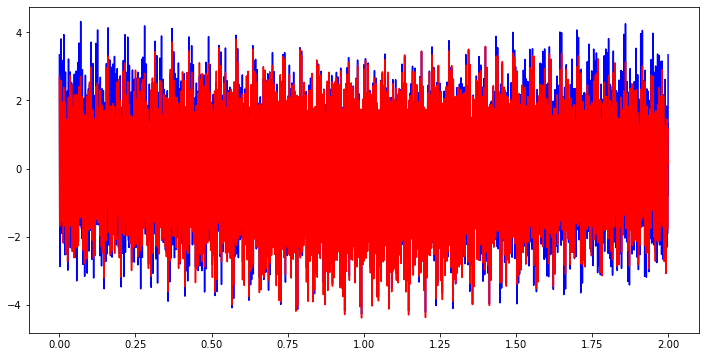

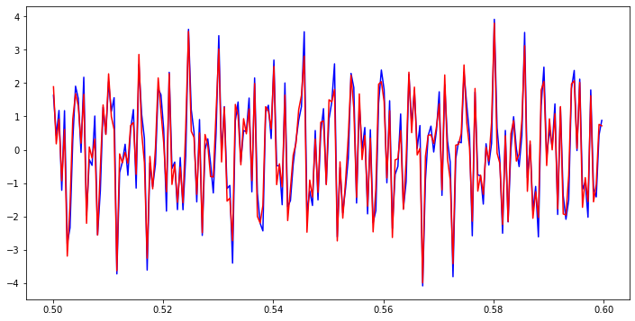

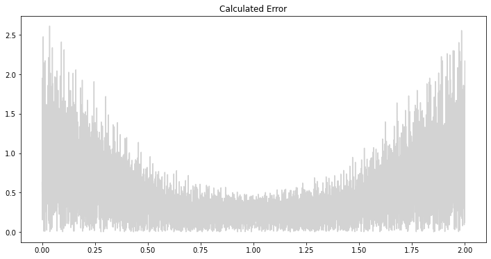

```python
amps_picked = signal_fft[indices_picked]*2/N
signal_recon = np.zeros_like(signal_fft)
for i in np.arange(int(N/2)):
    amp = signal_fft[i]/N*2
    #print(ffreq[i])
    if(i not in indices_picked):
        continue
    signal_recon += amp*np.exp(1j*i/N*2*np.pi*np.arange(N))

plt.plot(t,signal,"b-")
plt.plot(t,np.real(signal_recon),"r-")
plt.show()

time_window = [0.50,0.60]
t_filter = (t>=time_window[0]) & (t<=time_window[1])

plt.plot(t[t_filter], signal[t_filter],"b-")
plt.plot(t[t_filter], np.real(signal_recon[t_filter]),"r-")
plt.show()

plt.plot(t,np.abs(signal - np.real(signal_recon)),"-",
         color="lightgray")
plt.title("Calculated Error")
plt.show()
```

as can be seen, the errors are significantly higher on the edges. One way to remedy -as we had demonstrated in the "The importance of the number of samples (in regard to frequency splittings)" section, is to increase the number of samples. To see this, just increase the $N$ parameter at the beginning of this section (say 10 fold) and re-calculate - here it is:

```
[ 400  686 1152 1800]
```

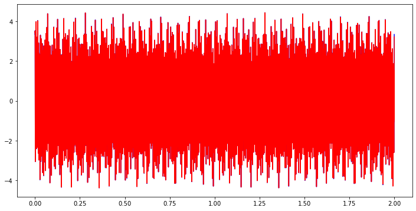

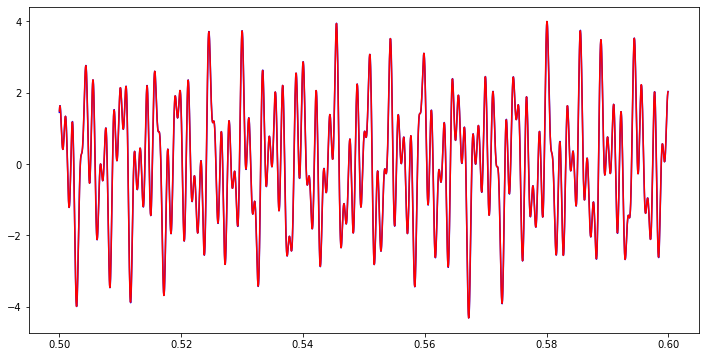

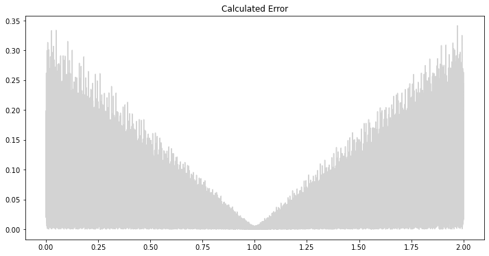

```python
N10 = 4000*10
freqs = [200, 343, 576, 900]
amps  = [1.2, 0.97, 1.13, 1.17]
funcs = [np.cos, np.cos, np.sin, np.cos]

t10 = np.linspace(0,2,N10)

two_pi_t10 = 2*np.pi*t10

signal10 = np.zeros(N10,float)
for i in range(len(freqs)):
    signal10 += amps[i] * funcs[i](two_pi_t10*freqs[i])

signal_fft10 = np.fft.fft(signal10)
ff10 = np.fft.fftfreq(N10,2/N10)

signal_fft_abs10 = np.abs(signal_fft10)
signal_fft_abs_normalized10 = signal_fft_abs10 / np.max(signal_fft_abs10)
f_norm_filter10 = signal_fft_abs_normalized10>0.5
ffreq10 = np.fft.fftfreq(N10,2/N10)
ffreq_pos_filter10 = ffreq10 > 0
f_filter10 = (f_norm_filter10) & (ffreq_pos_filter10)
indices_picked10 = np.arange(N10)[f_filter10]
print(indices_picked10)

amps_picked10 = signal_fft10[indices_picked10]*2/N10
signal_recon10 = np.zeros_like(signal_fft10)
for i in np.arange(int(N10/2)):
    amp10 = signal_fft10[i]/N10*2
    if(i not in indices_picked10):
        continue
    signal_recon10 += amp10*np.exp(1j*i/N10*2*np.pi*np.arange(N10))

plt.plot(t10,signal10,"b-")
plt.plot(t10,np.real(signal_recon10),"r-")
plt.show()

time_window = [0.50,0.60]
t_filter10 = (t10>=time_window[0]) & (t10<=time_window[1])
plt.plot(t10[t_filter10], signal10[t_filter10],"b-")
plt.plot(t10[t_filter10], np.real(signal_recon10[t_filter10]),"r-")
plt.show()

plt.plot(t10,np.abs(signal10 - np.real(signal_recon10)),"-",
         color="lightgray")
plt.title("Calculated Error")
plt.show()
```

But what happens if we do not have the opportunity to increase the number of samples (e.g., when we have already made our observations and it would be too impractical to re-do the measurements)? Then, we "use our heads" 8)

### Optimizing the amplitudes once we have obtained the frequencies (the real deal)

Let's go once again to our relatively low number of samples and take it from there: Remember that we had filtered out the frequencies with normalized amplitudes less than 0.5? Let's decrease that threshold to 0.1 and then try to reconstruct the original signal:

```
Indices Picked:
[ 400  401  685  686  687 1150 1151 1152 1153 1154 1798 1799 1800 1801
 1802 1803]
Frequencies Picked:
[200.  200.5 342.5 343.  343.5 575.  575.5 576.  576.5 577.  899.  899.5
 900.  900.5 901.  901.5]
```

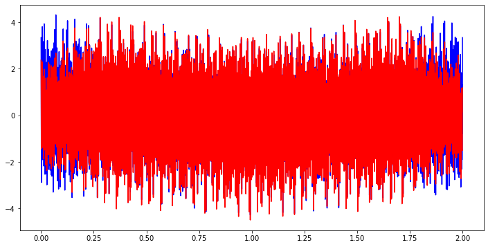

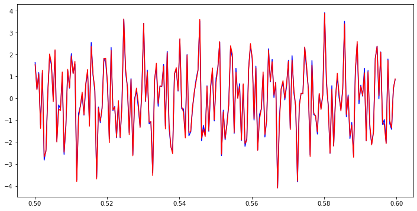

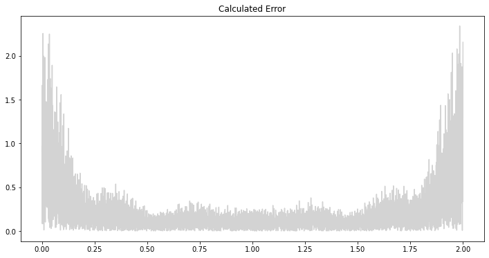

```python
N = 4000
freqs = [200, 343, 576, 900]
amps  = [1.2, 0.97, 1.13, 1.17]
funcs = [np.cos, np.cos, np.sin, np.cos]

threshold = 0.1

t = np.linspace(0,2,N)

two_pi_t = 2*np.pi*t

signal = np.zeros(N,float)
for i in range(len(freqs)):
    signal += amps[i] * funcs[i](two_pi_t*freqs[i])

signal_fft = np.fft.fft(signal)
ff = np.fft.fftfreq(N,2/N)

signal_fft_abs = np.abs(signal_fft)
signal_fft_abs_normalized = signal_fft_abs / np.max(signal_fft_abs)
f_norm_filter = signal_fft_abs_normalized>threshold
ffreq = np.fft.fftfreq(N,2/N)
ffreq_pos_filter = ffreq > 0
f_filter = (f_norm_filter) & (ffreq_pos_filter)
indices_picked = np.arange(N)[f_filter]
print("Indices Picked:")
print(indices_picked)
print("Frequencies Picked:")
print(ffreq[f_filter])
amps_picked = signal_fft[indices_picked]*2/N
signal_recon = np.zeros_like(signal_fft)
for i in np.arange(int(N/2)):
    amp = signal_fft[i]/N*2
    #print(ffreq[i])
    if(i not in indices_picked):
        continue
    signal_recon += amp*np.exp(1j*i/N*2*np.pi*np.arange(N))

plt.plot(t,signal,"b-")
plt.plot(t,np.real(signal_recon),"r-")
plt.show()

time_window = [0.50,0.60]
t_filter = (t>=time_window[0]) & (t<=time_window[1])

plt.plot(t[t_filter], signal[t_filter],"b-")
plt.plot(t[t_filter], np.real(signal_recon[t_filter]),"r-")
plt.show()

plt.plot(t,np.abs(signal - np.real(signal_recon)),"-",
         color="lightgray")
plt.title("Calculated Error")
plt.show()
```

Really much better indeed! Although by including all the "side" frequencies, we are actually losing the simplicity of the real signal. Even though the mathematical result is better, the physical point of view got much complicated. (This is the part where we'll start using our heads! 8)

Let's remember the frequencies and their corresponding amplitudes when we went for 50% amplitude filtering:

```python
peak_indices_filter = np.abs(signal_fft)>1000
freqs_recon_all = ff[peak_indices_filter]
freqs_recon_positive = freqs_recon_all[freqs_recon_all>0]
print(freqs_recon_positive)

indices_picked = []
amps_picked = []
for i in np.arange(N)[peak_indices_filter]:
    if(ff[i]>0):
        indices_picked.append(i)
        amps_picked.append(2*signal_fft[i]/N)
        print("[#{:4d}] {:6.2f} : {:7.3f} | {:.3f}".format(i,ff[i],
                                2*np.abs(signal_fft)[i]/N,amps_picked[-1]))
```

```
[200.  343.  576.  900.  900.5]
[# 400] 200.00 :   1.182 | 1.124+0.365j
[# 686] 343.00 :   0.924 | 0.794+0.474j
[#1152] 576.00 :   0.982 | 0.772-0.606j
[#1800] 900.00 :   0.818 | 0.127+0.808j
[#1801] 900.50 :   0.668 | -0.105-0.660j
```

The amplitudes are not that well spotted but now that we have the frequencies, they can be very easily be fitted (using a method like least squares fit - in a minute).

Speaking of frequencies, we see that the obtained frequencies of 900 and 900.5 are too close to be a coincidence, therefore we'll keep the 900 and leave 900.5. This leaves us with 4 frequencies (and even though we "don't know" it (as we had made ourselves forgotten once we built the original signal from them), they are the exact frequencies we had used). We have seen that, with the calculated amplitudes they yielded not-so-great results, therefore, we'll play with the amplitudes using the least-squares fitting method:

```python
# Ditch the 900.5 frequency from our picked list
freqs_picked = np.delete(freqs_recon_positive,-1)
amps_picked = np.delete(amps_picked,-1)
print(freqs_picked)
print(amps_picked)
```

```
[200. 343. 576. 900.]
[1.12405272+0.36505635j 0.79352649+0.47388979j 0.77234153-0.60601437j
 0.12723789+0.8082015j ]
```

At the moment, our summed up function looks like this:

```python
print("signal = ")
for i in np.arange(freqs_picked.size):
    amp_cos = amps_picked[i].real
    amp_sin = amps_picked[i].imag

    print("+",end="") if (i) else ""
    print(" "*5,"2*{:.3f}*cos(2*pi*({:.1f})t)".format(amp_cos,freqs_picked[i]),end="")
    print(" - 2*{:.3f}*sin(2*pi*({:.1f})t)".format(amp_sin,freqs_picked[i]))
```

```
signal =
      2*1.124*cos(2*pi*(200.0)t) - 2*0.365*sin(2*pi*(200.0)t)
+      2*0.794*cos(2*pi*(343.0)t) - 2*0.474*sin(2*pi*(343.0)t)
+      2*0.772*cos(2*pi*(576.0)t) - 2*-0.606*sin(2*pi*(576.0)t)
+      2*0.127*cos(2*pi*(900.0)t) - 2*0.808*sin(2*pi*(900.0)t)
```

and how different (/erroneous) is it from the original signal? Let's find out, but for practical purposes, let's define a function that takes these amplitudes as parameters (in the form of an array) and returns the difference:

```python
def fun_diff_sincos(A):
    sig_con = np.zeros_like(signal)
    for i in np.arange(freqs_picked.size):
            amp_cos = A[2*i]
            amp_sin = A[2*i+1]
            sig_con += amp_cos*np.cos(2*np.pi*freqs_picked[i]*t)
            sig_con -= amp_sin*np.sin(2*np.pi*freqs_picked[i]*t)
    return sig_con - signal
```

or, alternatively (& equivalently), using the exponential form:

```python
def fun_diff_exp(A):
    sig_con = np.zeros_like(signal,complex)
    for i in np.arange(freqs_picked.size):
            AA = A[2*i] + 1j*A[2*i+1]
            sig_con += AA * np.exp(1j*2*np.pi*freqs_picked[i]*t)
    return sig_con.real - signal
```

and here it is in action:

```
[ 1.12405272  0.36505635  0.79352649  0.47388979  0.77234153 -0.60601437
  0.12723789  0.8082015 ]
```

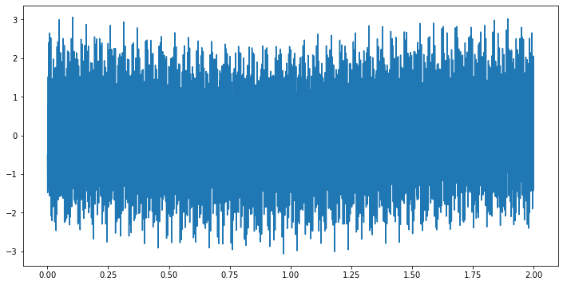

```python
amps_real = amps_picked.real
amps_imag = amps_picked.imag
A0 = np.vstack((amps_real,amps_imag)).T.flatten()
print(A0)
diff = fun_diff_sincos(A0)
plt.plot(t,diff)
plt.show()
```

`A0` is the array (/vector) that holds the amplitudes we had from the FFT, those will play a role as our *starting point*. We have included the real and imaginary parts as separate entries as most of the optimization functions are not supporting direct processing of complex parameters.

Our aim is to adjust the amplitudes vector to yield the minimum return (error) from our difference function. For this purpose we will use the least squares fitting method:

```python
from scipy.optimize import least_squares
A_opt = least_squares(fun_diff_sincos,A0).x
print(A_opt)

# exponential representation:
#A_opt_exp = least_squares(fun_diff_exp,A0).x
#print(A_opt_exp)
```

```
[ 1.20000000e+00 -8.49300505e-14  9.70000000e-01 -1.76198929e-13
 -2.60012306e-15 -1.13000000e+00  1.17000000e+00  1.13894769e-13]
```

Getting rid of zeros (<1E-10):

```python
A_opt[np.abs(A_opt)<1E-10] = 0
print(A_opt)
```

```
[ 1.2   0.    0.97  0.    0.   -1.13  1.17  0.  ]
```

Compare these with the input parameters:

```python
amps
```

```
[1.2, 0.97, 1.13, 1.17]
```

#### Negative coefficient for the sine???

At this moment, you might be wondering why did we implemented the sin part to the function as  
`sig_con -= amp_sin*np.sin(2*np.pi*freqs_picked[i]*t)` and also -directly as a result of that- got the amplitude as `-1.13`, instead of our input of `1.13`. The reason lies in the expansion of the amplitudes in the complex form - the details are given and derived in the "One Last Remark" section above, but the summary is the equivalency of:

$$\begin{align*}y_1 &= \left(a+ib\right)\left[\cos\left(2\pi (f) t\right) + i \sin\left(2\pi (f) t\right)\right]\\ y_2 &= \left(a-ib\right)\left[\cos\left(2\pi(-f) t\right) + i \sin\left(2\pi (-f) t\right)\right] \end{align*}$$$$\begin{gather*}y_1 + y_2 = \left(a+ib\right)\left[\cos\left(2\pi (f) t\right) + i \sin\left(2\pi (f) t\right)\right] + \left(a-ib\right)[\underbrace{\cos\left(2\pi(-f) t\right)}_{\cos\left(2\pi(f) t\right)} + i \,\underbrace{\sin\left(2\pi (-f) t\right)}_{-\sin\left(2\pi (f) t\right)}]\\ =\left[a\cos\left(2\pi f t\right)+ia\sin\left(2\pi f t\right)+ib\cos\left(2\pi f t\right)-b\sin\left(2\pi f t\right)\right] + \left[a\cos\left(2\pi f t\right)-ia\sin\left(2\pi f t\right)-ib\cos\left(2\pi f t\right)-b\sin\left(2\pi f t\right)\right]\\ =\boxed{2a\cos\left(2\pi f t\right) - 2b\sin\left(2\pi f t\right)} \end{gather*}$$

so, the amplitudes of the sine components come as subtraction! ;) (Mind that, when we have a signal made of pure cosines and sines, the magnitude of the amplitudes are the absolute values of the coefficients, hence the positive amplitudes: a complex coefficient like $0-1.13i$ has a magnitude of $1.13$). To see this more clearly, imagine that we only had a sine wave as the signal, say $1.3\sin(2\pi(576)t)$: Fourier transform would pick positive and negative frequencies in the form of:

$$(a + ib)[\cos(2\pi(576)t) + i\sin(2\pi(576)t)] \\+ (a - ib)[\cos(2\pi(-576)t) + i \sin(2\pi(-576)t)] $$

and we would equate this to our input signal of $1.3\sin(2\pi(576)t)$. Expanding the complex coefficient over the $\cos(\dots) + i \sin(\dots)$ and also using $\cos(-\theta)=\cos(\theta),\;\sin(-\theta)=-\sin(\theta)$ the addition of the positive and negative frequencies contributions would be:

$$2a\cos(2\pi(576)t) - 2b\sin(2\pi(576)t)$$

and equating it to our original wave, we'd have:

$$2a\cos(2\pi(576)t) - 2b\sin(2\pi(576)t) = 1.3\sin(2\pi(576)t)$$

From here, we see that $a=0$ while $-2b = 1.3$ hence the coefficient $2b$ is found out to be: $2b = -1.3$.

Let's rebuilt the signal from the obtained ones:

```
[1.2 +0.j   0.97+0.j   0.  -1.13j 1.17+0.j  ]
```

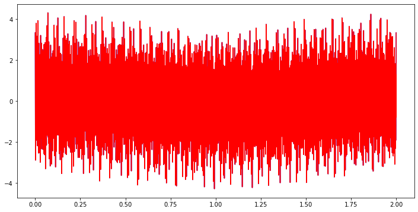

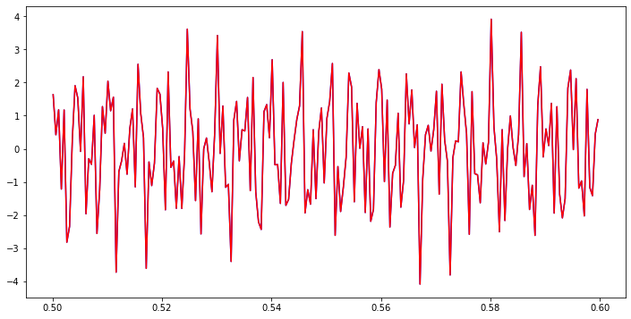

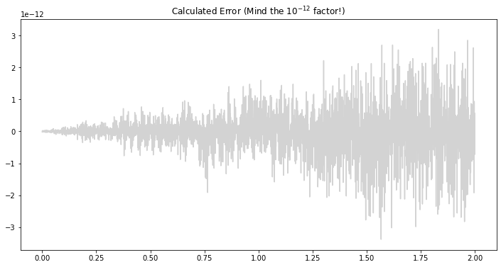

```python
A_complex = np.zeros(4,complex)
signal_re = np.zeros_like(signal,complex)
for i in np.arange(freqs_picked.size):
    A_complex[i] = A_opt[2*i] + 1j*A_opt[2*i+1]
    signal_re += A_complex[i] * np.exp(1j*2*np.pi*freqs_picked[i]*t)
print(A_complex)
plt.plot(t,signal,"b-")
plt.plot(t,signal_re.real,"r-")
plt.show()

time_window = [0.50,0.60]
t_filter = (t>=time_window[0]) & (t<=time_window[1])

plt.plot(t[t_filter], signal[t_filter],"b-")
plt.plot(t[t_filter], signal_re[t_filter].real,"r-")
plt.show()

plt.plot(t,fun_diff_sincos(A_opt),"-",color="lightgray")
plt.title("Calculated Error (Mind the $10^{-12}$ factor!)")
plt.show()
```

and there we have it! *<dance! dance! dance!>*